# Reproducible Research: Peer Assessment 1, Eino Palin

This code requires plyr, lattice packages. Also, the source file should be unzipped to the working directory

## Loading and preprocessing the data

Read the source data and convert the dates to correct format

```r
amd <- read.csv("activity.csv", header=TRUE)
amd$date <- as.Date(amd$date)
library(plyr)
library(lattice)
```

## What is mean total number of steps taken per day?

First, summarise the data with ddply, calculate the sum of steps per day and median and mean per day. Then make a histogram of the results and finally print the sum, mean and median per day

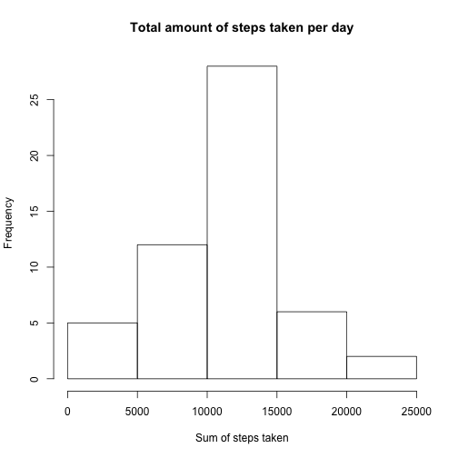

```r
sum_amd <- ddply(amd, "date", summarise, amdSum=sum(steps), amdMean=mean(steps), amdMedian=median(steps))
hist(sum_amd$amdSum, xlab="Sum of steps taken", main="Total amount of steps taken per day")
```

```r
dev.copy(png, file="figures/plot1.png")
```

```r
dev.off
```

[output not shown]

```r
sum_amd
```

```
##          date amdSum amdMean amdMedian
## 1  2012-10-01     NA      NA        NA
## 2  2012-10-02    126  0.4375         0
## 3  2012-10-03  11352 39.4167         0
## 4  2012-10-04  12116 42.0694         0
## 5  2012-10-05  13294 46.1597         0
## 6  2012-10-06  15420 53.5417         0
## 7  2012-10-07  11015 38.2465         0
## 8  2012-10-08     NA      NA        NA
## 9  2012-10-09  12811 44.4826         0
## 10 2012-10-10   9900 34.3750         0
## 11 2012-10-11  10304 35.7778         0
## 12 2012-10-12  17382 60.3542         0
## 13 2012-10-13  12426 43.1458         0
## 14 2012-10-14  15098 52.4236         0
```

[output cut: 47 more lines]

## What is the average daily activity pattern?

First, calculate the mean number of steps taken per time interval, across all days, then plot the results and print the interval where the maximum number of steps occur

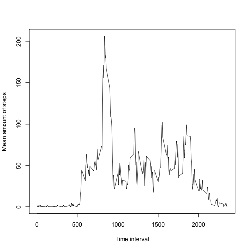

```r
mean_interval <- ddply(amd, "interval", summarise, intervallMean=mean(steps, na.rm=TRUE))
plot(mean_interval$interval, mean_interval$intervallMean, type="l", xlab="Time interval", ylab="Mean amount of steps")
```

```r
dev.copy(png, file="figures/plot2.png")
```

```r
dev.off
```

[output not shown]

```r
mean_interval[which.max(mean_interval$intervallMean),]
```

```
##     interval intervallMean
## 104      835         206.2
```

## Imputing missing values

First, calculate the amount rows with missing values, then replace the missing values with the correct interval mean, use ddply to calculate the sum of steps per day and median and mean per day, plot the results and print the new sum, mean and median per day

```r
sum(is.na(amd))
```

```
## [1] 2304
```

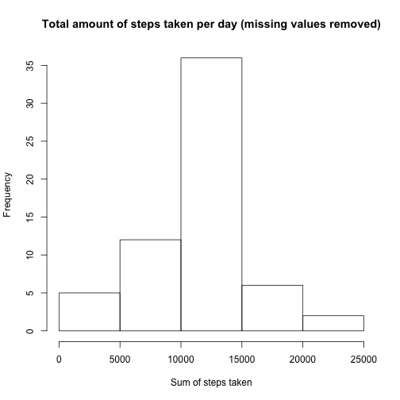

```r
amd[is.na(amd$steps) == "TRUE", 1] <- mean_interval$intervallMean
sum_amd_new <- ddply(amd, "date", summarise, amdSum=sum(steps), amdMean=mean(steps), amdMedian=median(steps))
hist(sum_amd_new$amdSum, xlab="Sum of steps taken", main="Total amount of steps taken per day (missing values removed)")
```

```r
dev.copy(png, file="figures/plot3.png")
```

```r
dev.off
```

[output not shown]

```r
sum_amd_new
```

```
##          date amdSum amdMean amdMedian
## 1  2012-10-01  10766 37.3826     34.11
## 2  2012-10-02    126  0.4375      0.00
## 3  2012-10-03  11352 39.4167      0.00
## 4  2012-10-04  12116 42.0694      0.00
## 5  2012-10-05  13294 46.1597      0.00
## 6  2012-10-06  15420 53.5417      0.00
## 7  2012-10-07  11015 38.2465      0.00
## 8  2012-10-08  10766 37.3826     34.11
## 9  2012-10-09  12811 44.4826      0.00
## 10 2012-10-10   9900 34.3750      0.00
## 11 2012-10-11  10304 35.7778      0.00
## 12 2012-10-12  17382 60.3542      0.00
## 13 2012-10-13  12426 43.1458      0.00
## 14 2012-10-14  15098 52.4236      0.00
```

[output cut: 47 more lines]

## Are there differences in activity patterns between weekdays and weekends?

First, add the new factor variable, isWeekday, then calculate the mean number of steps and plot the results

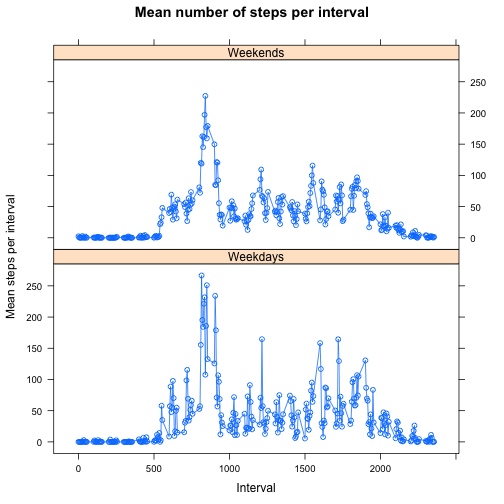

```r
amd$isWeekday <- !(weekdays(sum_amd$date)) %in% c('Saturday','Sunday')
steps_mean_wday <- ddply(amd, c("interval","isWeekday"), summarise, amd_Wday_mean=mean(steps))
xyplot(amd_Wday_mean ~ interval | isWeekday  , data=steps_mean_wday, type="b", xlab = "Interval", ylab ="Mean steps per interval", main="Mean number of steps per interval", strip=strip.custom(factor.levels=c("Weekdays", "Weekends")),layout=c(1,2))
```

```r
dev.copy(png, file="figures/plot4.png")
```

```r
dev.off
```

[output not shown]